# Analysing Titanic Data set

Ayush Bhargava

January 9, 2018

## Table of content

- Introduction
- Data Source
- Data Import
- Missing value Analysis
- Missing value imputation
- Feature Engineering
- Exploratory Analysis
- Data Preperation for prediction
- Prediction Models

## Introduction

This is my attempt at analysing Titanic data set, which is a very famous data set at [KAGGLE](https://www.kaggle.com/c/titanic). In this analysis i will first explore the dataset, try to understand dependent and independent variable. Then i will deal with missing values in the data set and perform feature engineering to extract as much information from given features as possible.Thereafter i will present visualizations of each features to gather some insights about their distribution and finally build predictive model and evaluate their performance.

## Data Source

Train and test data can be dowloaded from here:- https://www.kaggle.com/c/titanic/data Both train and test data sets are in standard csv format and has following features

Features in data set

| Variable | Definition | Key |
| --- | --- | --- |
| Survived | Surival | 0 = No, 1 = Yes |
| pclass | Passenger class | 1 = 1st, 2 = 2nd, 3 = 3rd |
| sex | sex |  |
| Age | age in years |  |
| sibps | # of siblings / spouses aboard the Titanic |  |
| parch | # of parents / children aboard the Titanic |  |
| ticket | ticket number |  |
| fare | passenger fare |  |
| cabin | cabin number |  |
| embarked | Port of embarkation | C = Cherbourg, Q = Queenstown, S = Southampton |

## Data import

### Loading Required Libraries

```r
# data wrangling
library(tidyverse)
library(forcats)
library(stringr)

#data imputation
library(mice)

# data assessment/visualizations
library(tm)
library(data.table)
library(pander)
library(ggplot2)
library(scales)
library(grid)
library(gridExtra)
library(corrplot)
library(VIM)
library(knitr)
library(vcd)
library(caret)

# model
library(xgboost)
library(MLmetrics)
library('randomForest')
library('rpart')
library('rpart.plot')
library('car')
library('e1071')
```

### Setting up working directory and getting data

```r
setwd("C:/Users/ichbi/Desktop/kaggle/Titanic")
train <- read_csv('train.csv')
test <- read_csv('test.csv')
```

Here we are using read_csv as it is faster than read.csv and doesnot convert string as factor by default. Next we will sneak peak the train data set and do some preprocessing. we will convert some variables in to factor variable for ease of analysis

### Train data preprocessing

```r
#sneak peak
glimpse(train)
```

```
## Observations: 891
## Variables: 12
## $ PassengerId <int> 1, 2, 3, 4, 5, 6, 7, 8, 9, 10, 11, 12, 13, 14, 15,...
## $ Survived    <int> 0, 1, 1, 1, 0, 0, 0, 0, 1, 1, 1, 1, 0, 0, 0, 1, 0,...
## $ Pclass      <int> 3, 1, 3, 1, 3, 3, 1, 3, 3, 2, 3, 1, 3, 3, 3, 2, 3,...
## $ Name        <chr> "Braund, Mr. Owen Harris", "Cumings, Mrs. John Bra...
## $ Sex         <chr> "male", "female", "female", "female", "male", "mal...
## $ Age         <dbl> 22, 38, 26, 35, 35, NA, 54, 2, 27, 14, 4, 58, 20, ...
## $ SibSp       <int> 1, 1, 0, 1, 0, 0, 0, 3, 0, 1, 1, 0, 0, 1, 0, 0, 4,...
## $ Parch       <int> 0, 0, 0, 0, 0, 0, 0, 1, 2, 0, 1, 0, 0, 5, 0, 0, 1,...
## $ Ticket      <chr> "A/5 21171", "PC 17599", "STON/O2. 3101282", "1138...
## $ Fare        <dbl> 7.2500, 71.2833, 7.9250, 53.1000, 8.0500, 8.4583, ...
## $ Cabin       <chr> NA, "C85", NA, "C123", NA, NA, "E46", NA, NA, NA, ...
## $ Embarked    <chr> "S", "C", "S", "S", "S", "Q", "S", "S", "S", "C", ...
```

```r
#converting in to factors
train <- train %>% setNames(tolower(names(.))) %>% mutate(survived=factor(survived, levels = c("0","1"), labels = c("0","1")),pclass=factor(pclass), sex=factor(sex),embarked=factor(embarked), set='train')

#looking at the summary
summary(train)
```

```
##   passengerid    survived pclass      name               sex
##  Min.   :  1.0   0:549    1:216   Length:891         female:314
##  1st Qu.:223.5   1:342    2:184   Class :character   male  :577
##  Median :446.0            3:491   Mode  :character
##  Mean   :446.0
##  3rd Qu.:668.5
##  Max.   :891.0
##
##       age            sibsp           parch           ticket
##  Min.   : 0.42   Min.   :0.000   Min.   :0.0000   Length:891
##  1st Qu.:20.12   1st Qu.:0.000   1st Qu.:0.0000   Class :character
##  Median :28.00   Median :0.000   Median :0.0000   Mode  :character
##  Mean   :29.70   Mean   :0.523   Mean   :0.3816
##  3rd Qu.:38.00   3rd Qu.:1.000   3rd Qu.:0.0000
##  Max.   :80.00   Max.   :8.000   Max.   :6.0000
##  NA's   :177
##       fare           cabin           embarked       set
##  Min.   :  0.00   Length:891         C   :168   Length:891
##  1st Qu.:  7.91   Class :character   Q   : 77   Class :character
##  Median : 14.45   Mode  :character   S   :644   Mode  :character
##  Mean   : 32.20                      NA's:  2
##  3rd Qu.: 31.00
##  Max.   :512.33
##
```

```r
#percentage survived
surv_pct <- train %>% count(survived) %>% mutate(pct=n/sum(n)) %>% setNames(c('survived','count','percentage')) %>% as.data.frame() %>% mutate(survived=ifelse(survived==0,'No','Yes'))
```

There is no survived column in the test set and our goal is to build a predictive model on train set and predict survival of passengers in the test set.

### Test data preprocessing

```r
#sneak peak
glimpse(test)
```

```
## Observations: 418
## Variables: 11
## $ PassengerId <int> 892, 893, 894, 895, 896, 897, 898, 899, 900, 901, ...
## $ Pclass      <int> 3, 3, 2, 3, 3, 3, 3, 2, 3, 3, 3, 1, 1, 2, 1, 2, 2,...
## $ Name        <chr> "Kelly, Mr. James", "Wilkes, Mrs. James (Ellen Nee...
## $ Sex         <chr> "male", "female", "male", "male", "female", "male"...
## $ Age         <dbl> 34.5, 47.0, 62.0, 27.0, 22.0, 14.0, 30.0, 26.0, 18...
## $ SibSp       <int> 0, 1, 0, 0, 1, 0, 0, 1, 0, 2, 0, 0, 1, 1, 1, 1, 0,...
## $ Parch       <int> 0, 0, 0, 0, 1, 0, 0, 1, 0, 0, 0, 0, 0, 0, 0, 0, 0,...
## $ Ticket      <chr> "330911", "363272", "240276", "315154", "3101298",...
## $ Fare        <dbl> 7.8292, 7.0000, 9.6875, 8.6625, 12.2875, 9.2250, 7...
## $ Cabin       <chr> NA, NA, NA, NA, NA, NA, NA, NA, NA, NA, NA, NA, "B...
## $ Embarked    <chr> "Q", "S", "Q", "S", "S", "S", "Q", "S", "C", "S", ...
```

```r
#converting in to factors
test <- test %>% setNames(tolower(names(.))) %>% mutate(pclass=factor(pclass), sex=factor(sex),embarked=factor(embarked), set='test')

#looking at the summary
summary(test)
```

```
##   passengerid     pclass      name               sex           age
##  Min.   : 892.0   1:107   Length:418         female:152   Min.   : 0.17
##  1st Qu.: 996.2   2: 93   Class :character   male  :266   1st Qu.:21.00
##  Median :1100.5   3:218   Mode  :character                Median :27.00
##  Mean   :1100.5                                           Mean   :30.27
##  3rd Qu.:1204.8                                           3rd Qu.:39.00
##  Max.   :1309.0                                           Max.   :76.00
##                                                           NA's   :86
##      sibsp            parch           ticket               fare
##  Min.   :0.0000   Min.   :0.0000   Length:418         Min.   :  0.000
##  1st Qu.:0.0000   1st Qu.:0.0000   Class :character   1st Qu.:  7.896
##  Median :0.0000   Median :0.0000   Mode  :character   Median : 14.454
##  Mean   :0.4474   Mean   :0.3923                      Mean   : 35.627
##  3rd Qu.:1.0000   3rd Qu.:0.0000                      3rd Qu.: 31.500
##  Max.   :8.0000   Max.   :9.0000                      Max.   :512.329
##                                                       NA's   :1
##     cabin           embarked     set
##  Length:418         C:102    Length:418
##  Class :character   Q: 46    Class :character
##  Mode  :character   S:270    Mode  :character
##
##
##
##
```

- For doing feature engineering and preprocessing for modeling and there after predicting, we will comine train and test set so that features are consistent amoung two data sets
- Just before building models we will again divide the train and test set

### Merging test and train data sets

```r
#bind_row will row bind and will fill NA values in survived column for test set passengers
full <- bind_rows(train,test)
summary(full)
```

```
##   passengerid   survived   pclass      name               sex
##  Min.   :   1   0   :549   1:323   Length:1309        female:466
##  1st Qu.: 328   1   :342   2:277   Class :character   male  :843
##  Median : 655   NA's:418   3:709   Mode  :character
##  Mean   : 655
##  3rd Qu.: 982
##  Max.   :1309
##
##       age            sibsp            parch          ticket
##  Min.   : 0.17   Min.   :0.0000   Min.   :0.000   Length:1309
##  1st Qu.:21.00   1st Qu.:0.0000   1st Qu.:0.000   Class :character
##  Median :28.00   Median :0.0000   Median :0.000   Mode  :character
##  Mean   :29.88   Mean   :0.4989   Mean   :0.385
##  3rd Qu.:39.00   3rd Qu.:1.0000   3rd Qu.:0.000
##  Max.   :80.00   Max.   :8.0000   Max.   :9.000
##  NA's   :263
##       fare            cabin           embarked       set
##  Min.   :  0.000   Length:1309        C   :270   Length:1309
##  1st Qu.:  7.896   Class :character   Q   :123   Class :character
##  Median : 14.454   Mode  :character   S   :914   Mode  :character
##  Mean   : 33.295                      NA's:  2
##  3rd Qu.: 31.275
##  Max.   :512.329
##  NA's   :1
```

```r
glimpse(full)
```

```
## Observations: 1,309
## Variables: 13
## $ passengerid <int> 1, 2, 3, 4, 5, 6, 7, 8, 9, 10, 11, 12, 13, 14, 15,...
## $ survived    <fctr> 0, 1, 1, 1, 0, 0, 0, 0, 1, 1, 1, 1, 0, 0, 0, 1, 0...
## $ pclass      <fctr> 3, 1, 3, 1, 3, 3, 1, 3, 3, 2, 3, 1, 3, 3, 3, 2, 3...
## $ name        <chr> "Braund, Mr. Owen Harris", "Cumings, Mrs. John Bra...
## $ sex         <fctr> male, female, female, female, male, male, male, m...
## $ age         <dbl> 22, 38, 26, 35, 35, NA, 54, 2, 27, 14, 4, 58, 20, ...
## $ sibsp       <int> 1, 1, 0, 1, 0, 0, 0, 3, 0, 1, 1, 0, 0, 1, 0, 0, 4,...
## $ parch       <int> 0, 0, 0, 0, 0, 0, 0, 1, 2, 0, 1, 0, 0, 5, 0, 0, 1,...
## $ ticket      <chr> "A/5 21171", "PC 17599", "STON/O2. 3101282", "1138...
## $ fare        <dbl> 7.2500, 71.2833, 7.9250, 53.1000, 8.0500, 8.4583, ...
## $ cabin       <chr> NA, "C85", NA, "C123", NA, NA, "E46", NA, NA, NA, ...
## $ embarked    <fctr> S, C, S, S, S, Q, S, S, S, C, S, S, S, S, S, S, Q...
## $ set         <chr> "train", "train", "train", "train", "train", "trai...
```

## Missing Value analysis

Next we will look if there are any missing values in our data set. first we will build a table with count and percentage of missing values for every feature in our data set and later we will visualize the same data

```r
#Creating table of count of missing values in features of our full dataset
miss_values <- full %>% summarise_all(funs(count=sum(is.na(.)),percentage=sum(is.na(.))/n()))
miss_count <- miss_values[,1:12] %>% gather(variable, miss_count)
miss_count
```

```
## # A tibble: 12 x 2
##    variable          miss_count
##    <chr>                  <int>
##  1 passengerid_count          0
##  2 survived_count           418
##  3 pclass_count               0
##  4 name_count                 0
##  5 sex_count                  0
##  6 age_count                263
##  7 sibsp_count                0
##  8 parch_count                0
##  9 ticket_count               0
## 10 fare_count                 1
## 11 cabin_count             1014
## 12 embarked_count             2
```

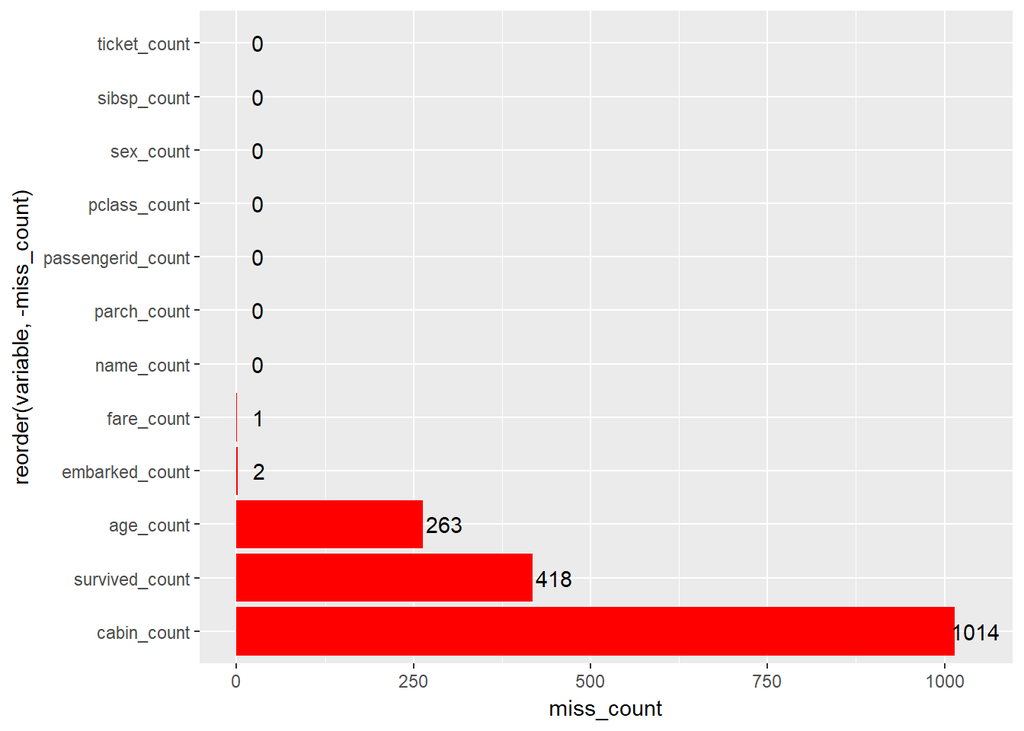

```r
#visualizing
miss_count %>% ggplot(aes(x=reorder(variable,-miss_count),y=miss_count)) + geom_bar(stat='identity',fill='red') + geom_text(aes(y=miss_count+30,label=miss_count))+coord_flip()
```

```r
#Creating table of percentage of missing values in features of our full dataset
miss_percentage <- miss_values[,13:24] %>% gather(variable, miss_percentage)
miss_percentage
```

```
## # A tibble: 12 x 2
##    variable               miss_percentage
##    <chr>                            <dbl>
##  1 set_count                     0
##  2 passengerid_percentage        0
##  3 survived_percentage           0.319
##  4 pclass_percentage             0
##  5 name_percentage               0
##  6 sex_percentage                0
##  7 age_percentage                0.201
##  8 sibsp_percentage              0
##  9 parch_percentage              0
## 10 ticket_percentage             0
## 11 fare_percentage               0.000764
## 12 cabin_percentage              0.775
```

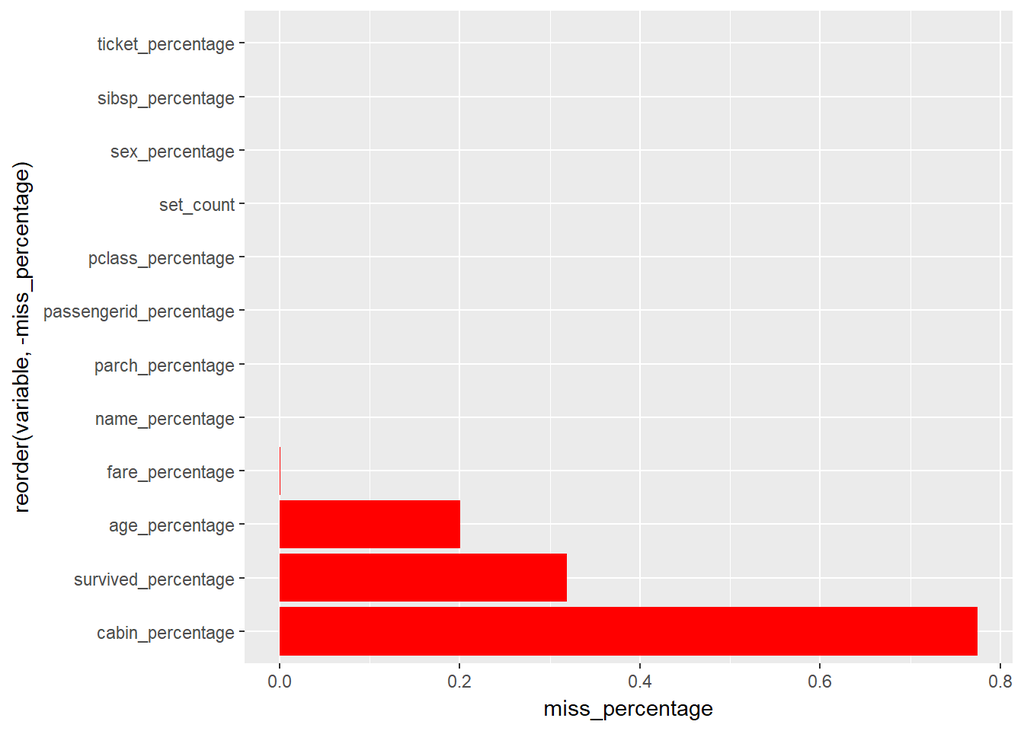

```r
#Visualizing
miss_percentage %>% ggplot(aes(x=reorder(variable,-miss_percentage),y=miss_percentage)) + geom_bar(stat='identity',fill='red') +coord_flip()
```

## Missing value Imputation

### Embarkement :-

This variable could be related to fare and pclass variable, lets look at the whole feature space of these missing points

```r
glimpse(full %>% filter(is.na(embarked)))
```

```
## Observations: 2
## Variables: 13
## $ passengerid <int> 62, 830
## $ survived    <fctr> 1, 1
## $ pclass      <fctr> 1, 1
## $ name        <chr> "Icard, Miss. Amelie", "Stone, Mrs. George Nelson ...
## $ sex         <fctr> female, female
## $ age         <dbl> 38, 62
## $ sibsp       <int> 0, 0
## $ parch       <int> 0, 0
## $ ticket      <chr> "113572", "113572"
## $ fare        <dbl> 80, 80
## $ cabin       <chr> "B28", "B28"
## $ embarked    <fctr> NA, NA
## $ set         <chr> "train", "train"
```

Now we know that these are 1st class females who paid 80 fare. lets look at relationship between pclass vs fare vs embarkemnt and see if we could decipher any useful information about emabarkment of these passengers

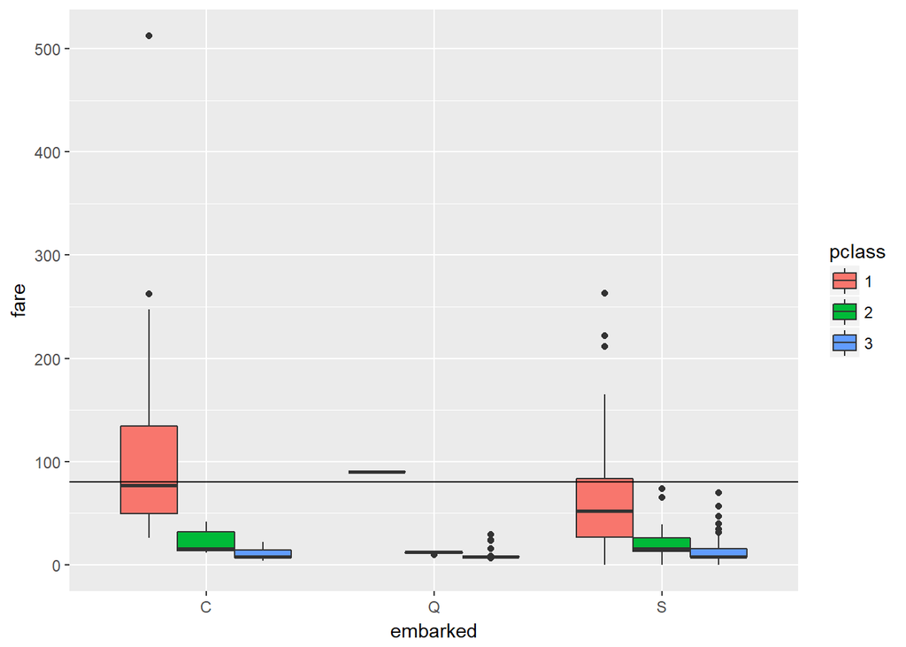

```r
#subseting the non missing embarked
embark_full <- full %>% filter(!is.na(embarked))

#plotting
ggplot(embark_full, aes(x=embarked,y=fare, fill=pclass))+geom_boxplot()+geom_hline(yintercept = 80)
```

It is clearly visible in the plot that passenger of 1st class embarked from “C” paid a fare of 80 on average, thus it is safe to impute “c” for these missing embarked passengers

#### Imputing value and getting the imputed data set

```r
full <- full %>% mutate(embarked=factor(ifelse(is.na(full$embarked),'C', as.character(embarked))))
```

### Fare :-

lets look at the whole feature space of the missing point

```r
glimpse(full %>% filter(is.na(fare)))
```

```
## Observations: 1
## Variables: 13
## $ passengerid <int> 1044
## $ survived    <fctr> NA
## $ pclass      <fctr> 3
## $ name        <chr> "Storey, Mr. Thomas"
## $ sex         <fctr> male
## $ age         <dbl> 60.5
## $ sibsp       <int> 0
## $ parch       <int> 0
## $ ticket      <chr> "3701"
## $ fare        <dbl> NA
## $ cabin       <chr> NA
## $ embarked    <fctr> S
## $ set         <chr> "test"
```

embarked = s, pclass=3, since only one value is missing lets plug with the median in this category

#### Imputing value and getting the imputed data set

```r
impte_value <- full %>% group_by(embarked, pclass) %>% summarise(mean_fare=median(fare,na.rm=T)) %>% filter(embarked=='S',pclass==3) %>% .$mean_fare
full <- full %>% mutate(fare=ifelse(is.na(full$fare),impte_value,fare))
```

### Age :-

We saw earlier there are many missing points in age feature, thus we will use mice imputation, which is a neat implementation of data imputation. more can be read about mice imputation [here](http://www.jstatsoft.org/article/view/v045i03/v45i03.pdf)

```r
#creating dataset for mice imputation
  mice_data <- full[,!names(full) %in% c('passengerid','name','ticket','cabin','survived')]
 set.seed(120)
 imputed_data <- mice(mice_data, method = 'rf')
imputed_data <- mice::complete(imputed_data)
```

lets compare age distribution in original and imputed data set

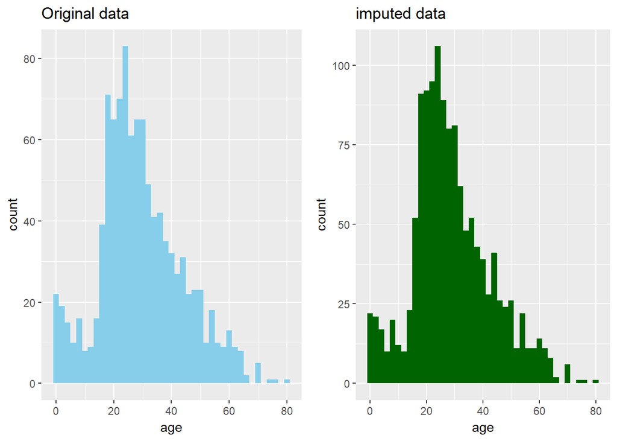

```r
#comparing age distribution in original and imputed data
 par_1 <- ggplot(full, aes(x=age)) + geom_histogram(fill='skyblue', binwidth = 2) + labs(title="Original data")
 par_2 <- ggplot(imputed_data, aes(x=age)) + geom_histogram(fill='darkgreen', binwidth = 2) + labs(title="imputed data")
grid.arrange(par_1, par_2, ncol=2)
```

Age distribution in imputed dataset seems is in line with the original dataset, lets replace age in original data set with imputed value

```r
#finally replacing age variable in full data set
full$age <- imputed_data$age
```

## Feature Engineering

There are features in data set which contains more information that could potentailly reduce bais in our prediction models. This information is not implicitly visible and has to be extracted. This process is feature engineering.

### Creating Title

From the name variable we can extract title of a passenger to add more information for training our model

```r
full$title <- gsub("^.*,[[:blank:]](.*?)\\..*$", "\\1", full$name)
table(full$title)
```

```
##
##         Capt          Col          Don         Dona           Dr
##            1            4            1            1            8
##     Jonkheer         Lady        Major       Master         Miss
##            1            1            2           61          260
##         Mlle          Mme           Mr          Mrs           Ms
##            2            1          757          197            2
##          Rev          Sir the Countess
##            8            1            1
```

```r
rare <- c('the Countess','Capt', 'Col', 'Don',
            'Dr', 'Major', 'Rev', 'Sir', 'Jonkheer')
full$title[full$title == 'Mlle'] <- 'Miss'
full$title[full$title == 'Ms']   <- 'Miss'
full$title[full$title == 'Mme']  <- 'Mrs'
full$title[full$title == 'Lady'] <- 'Miss'
full$title[full$title == 'Dona'] <- 'Miss'
full$title[full$title %in% rare] <- "rare"
table(full$title)
```

```
##
## Master   Miss     Mr    Mrs   rare
##     61    266    757    198     27
```

```r
full$title <- factor(full$title)
```

We have grabbed the title from the name and categorised them on the basis of occurance in the data set to avoid outliers. we will explore the surivival on the basis of title in the next section

### Family size

We will explore Whether size of family matter in the survival. we will create a family size variable by adding no of siblings (sibps) and no of parents variable(parch)

```r
full$familysize <- full$sibsp +full$parch +1
full$FamilySized[full$familysize == 1] <- 'Single'
full$FamilySized[full$familysize < 5 & full$familysize >= 2] <- 'Small'
full$FamilySized[full$familysize >= 5] <- 'Big'
full$FamilySized=as.factor(full$FamilySized)
```

To avoid outliers we have created categories of family size

### Age groups

To analyse age variable lets categorise this variable too

```r
full <- full %>% mutate(agegroup=case_when(age<13 ~"children", (age >= 13 & age< 18) ~ "adolsents", (age >=18 & age<60) ~ "adults", age>=60 ~ "aged")) %>% mutate(agegroup=factor(agegroup))
```

### Ticket groups

Ticket variable does not seem to provide useful information, to use this variable we will do some text mining and find pattern in the ticket number and finally creating groups based on pattern.

It was found that there are ticket numbers which are numeric with 3,4,5,6,7 digits and than there are ticket numbers which starts with certain letters, we have created a variable ticket group based on these observed pattern.

```r
#Ticket
full <- full %>% mutate(ticketgroup= tolower(ticket)) %>% mutate(ticketgroup=removePunctuation(ticketgroup)) %>% mutate(ticketgroup=gsub(" ","", ticketgroup)) %>% mutate(ticketgroup= case_when(grepl('^[0-9]', ticketgroup) & nchar(ticketgroup)==3 ~ "numeric3", grepl('^[0-9]', ticketgroup) & nchar(ticketgroup)==4 ~ "numeric4",grepl('^[0-9]', ticketgroup) & nchar(ticketgroup)==5 ~ "numeric5",grepl('^[0-9]', ticketgroup) & nchar(ticketgroup)==6 ~ "numeric6",grepl('^[0-9]', ticketgroup) & nchar(ticketgroup)==7 ~ "numeric7", grepl("^(a)", ticketgroup) ~ "a",grepl("^(c)", ticketgroup) ~ "c",grepl("^(f)", ticketgroup)|grepl("^(l)", ticketgroup) ~ "f",grepl("^(p)", ticketgroup)~ "p",grepl("^(s)", ticketgroup)~"s",grepl("^(w)", ticketgroup)~"w" ))%>% mutate(ticketgroup=factor(ticketgroup))
```

### survival vs other relevant variables

#### Pclass

```r
summary <- full %>% filter(set=='train') %>% group_by(pclass) %>% summarise(passenger=n(),survived=sum(as.numeric(as.character(survived))), survival_rate= round(sum(as.numeric(as.character(survived)))*100/n()))
kable(summary)
```

| pclass | passenger | survived | survival_rate |
| --- | --- | --- | --- |
| 1 | 216 | 136 | 63 |
| 2 | 184 | 87 | 47 |
| 3 | 491 | 119 | 24 |

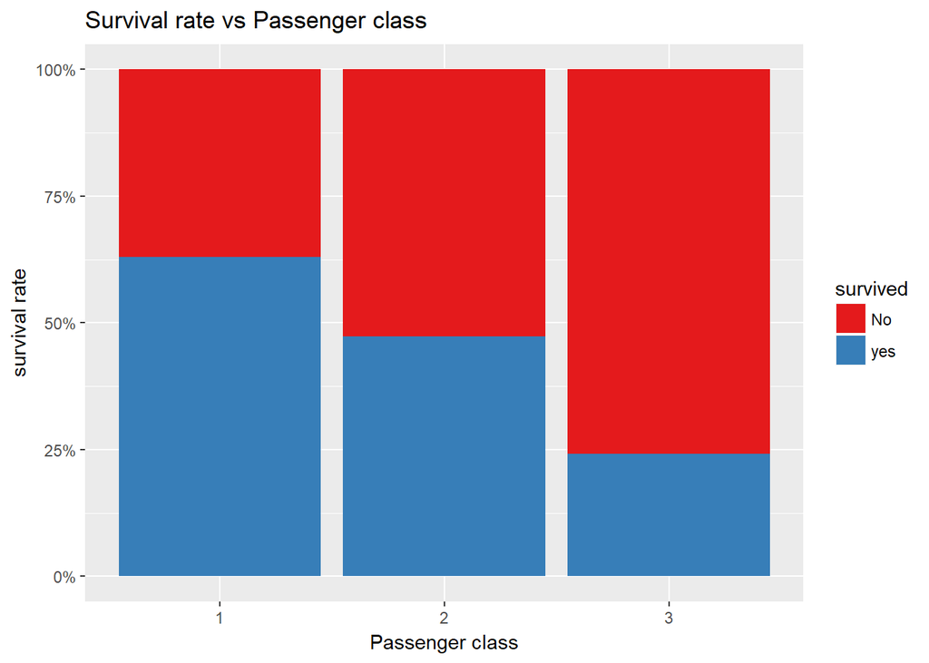

```r
ggplot(full %>% mutate(survived=case_when(survived==0 ~ "No", survived==1 ~'yes'))  %>% filter(set=='train'), aes(x=pclass, fill=survived))+geom_bar(position = "fill")+scale_fill_brewer(palette="Set1")+ scale_y_continuous(labels = percent)+labs(x='Passenger class', y= "survival rate", title ="Survival rate vs Passenger class")      #use RColorBrewer::display.brewer.all() to check pallet options
```

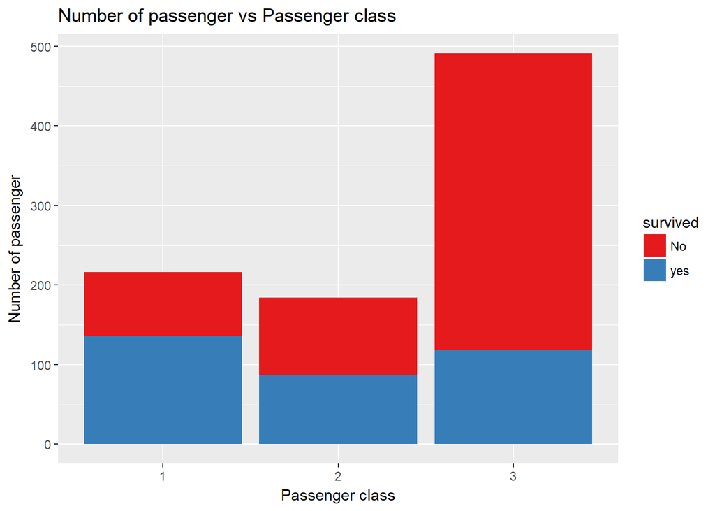

```r
ggplot(full %>% mutate(survived=case_when(survived==0 ~ "No", survived==1 ~'yes'))  %>% filter(set=='train'), aes(x=pclass, fill=survived))+geom_bar()+scale_fill_brewer(palette="Set1")+labs(x='Passenger class', y= "Number of passenger", title ="Number of passenger vs Passenger class")      #use RColorBrewer::display.brewer.all() to check pallet options
```

#### Sex

```r
summary <- full %>% filter(set=='train') %>% group_by(sex) %>% summarise(passenger=n(),survived=sum(as.numeric(as.character(survived))), survival_rate= round(sum(as.numeric(as.character(survived)))*100/n()))
kable(summary)
```

| sex | passenger | survived | survival_rate |
| --- | --- | --- | --- |
| female | 314 | 233 | 74 |
| male | 577 | 109 | 19 |

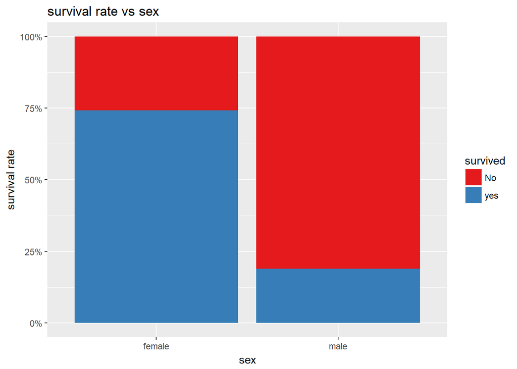

```r
ggplot(full %>% mutate(survived=case_when(survived==0 ~ "No", survived==1 ~'yes'))  %>% filter(set=='train'), aes(x=sex, fill=survived))+geom_bar(position = "fill")+scale_fill_brewer(palette="Set1")+ scale_y_continuous(labels = percent)+labs(x='sex', y= "survival rate", title ="survival rate vs sex")      #use RColorBrewer::display.brewer.all() to check pallet options
```

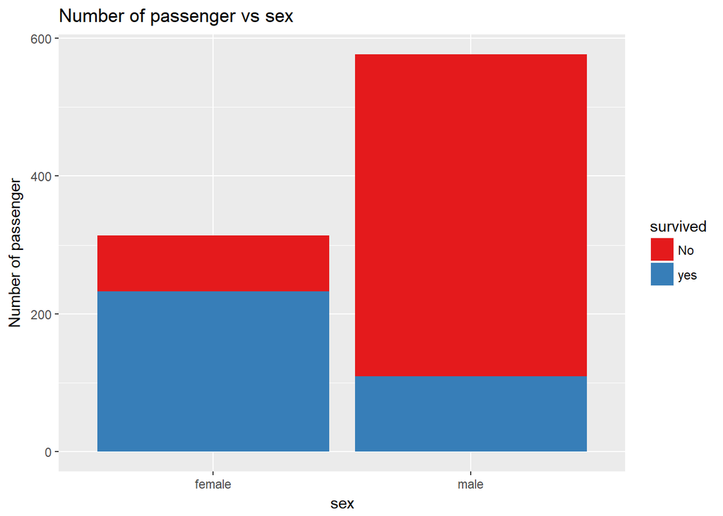

```r
ggplot(full %>% mutate(survived=case_when(survived==0 ~ "No", survived==1 ~'yes'))  %>% filter(set=='train'), aes(x=sex, fill=survived))+geom_bar()+scale_fill_brewer(palette="Set1")+labs(x='sex', y= "Number of passenger", title ="Number of passenger vs sex")      #use RColorBrewer::display.brewer.all() to check pallet options
```

#### Age

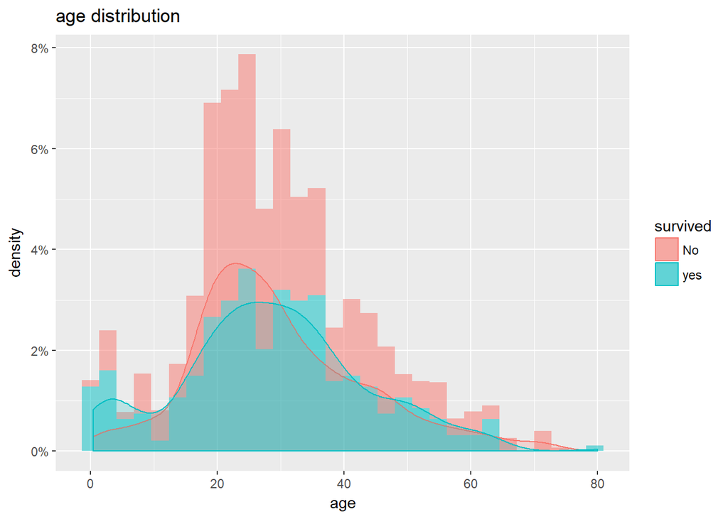

```r
ggplot(full %>% mutate(survived=case_when(survived==0 ~ "No", survived==1 ~'yes'))  %>% filter(set=='train'),aes(x=age, fill=survived))+geom_histogram(aes(y=..density..), alpha=0.5)+geom_density(alpha=0.2,aes(colour=survived))+scale_y_continuous(label=percent)+labs(x="age",y='density', title="age distribution")
```

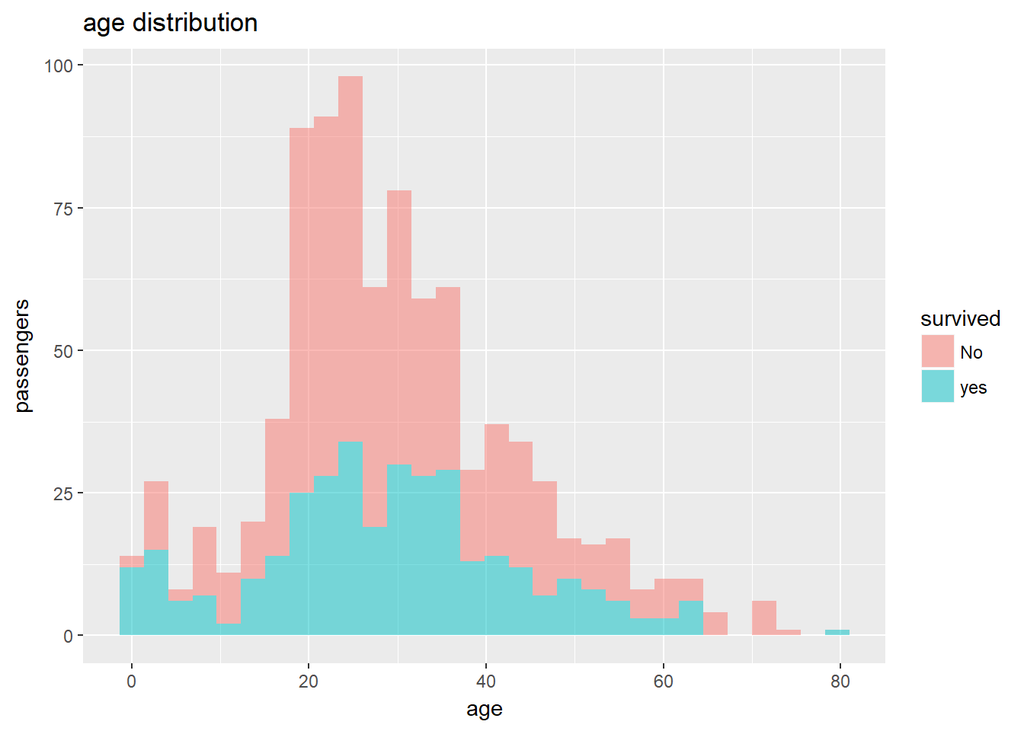

```r
ggplot(full %>% mutate(survived=case_when(survived==0 ~ "No", survived==1 ~'yes'))  %>% filter(set=='train'),aes(x=age, fill=survived))+geom_histogram(alpha=0.5)+labs(x="age",y='passengers', title="age distribution")
```

#### Agegroup

```r
summary <- full %>% filter(set=='train') %>% group_by(agegroup) %>% summarise(passenger=n(),survived=sum(as.numeric(as.character(survived))), survival_rate= round(sum(as.numeric(as.character(survived)))*100/n()))
kable(summary)
```

| agegroup | passenger | survived | survival_rate |
| --- | --- | --- | --- |
| adolsents | 58 | 24 | 41 |
| adults | 724 | 266 | 37 |
| aged | 30 | 10 | 33 |
| children | 79 | 42 | 53 |

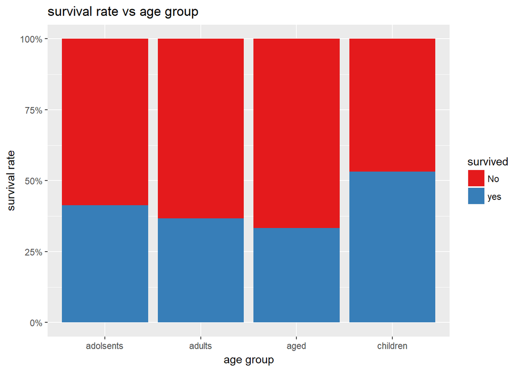

```r
ggplot(full %>% mutate(survived=case_when(survived==0 ~ "No", survived==1 ~'yes'))  %>% filter(set=='train'), aes(x=agegroup, fill=survived))+geom_bar(position = "fill")+scale_fill_brewer(palette="Set1")+ scale_y_continuous(labels = percent)+labs(x='age group', y= "survival rate", title ="survival rate vs age group")      #use RColorBrewer::display.brewer.all() to check pallet options
```

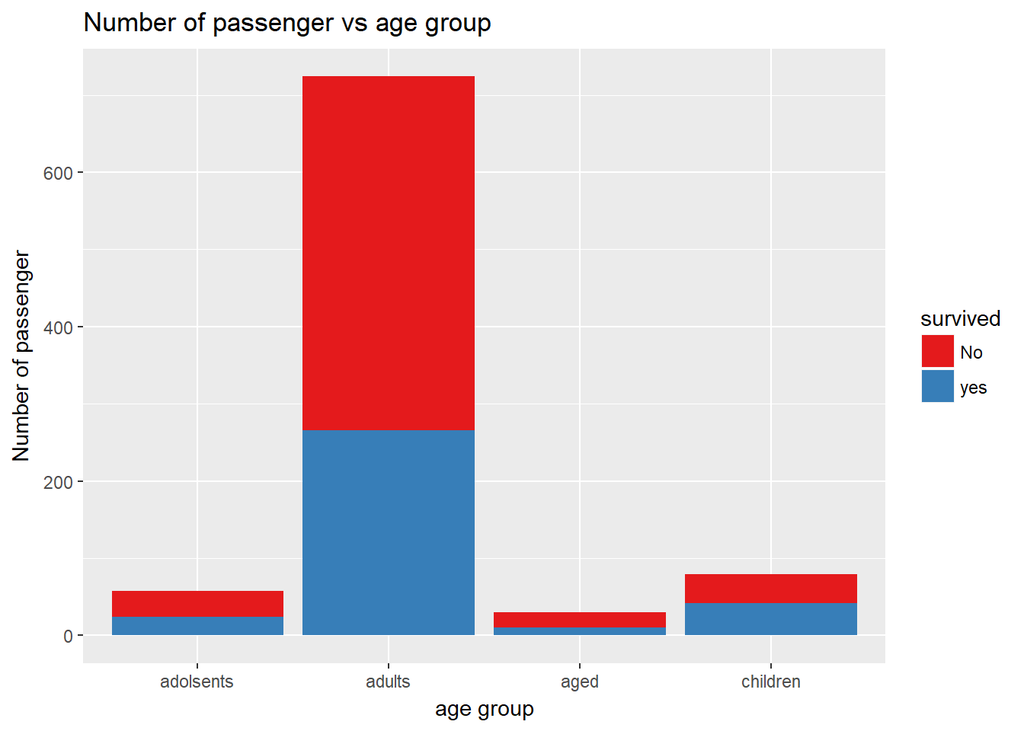

```r
ggplot(full %>% mutate(survived=case_when(survived==0 ~ "No", survived==1 ~'yes'))  %>% filter(set=='train'), aes(x=agegroup, fill=survived))+geom_bar()+scale_fill_brewer(palette="Set1")+labs(x='age group', y= "Number of passenger", title ="Number of passenger vs age group")      #use RColorBrewer::display.brewer.all() to check pallet options
```

#### Sibsp

```r
summary <- full %>% filter(set=='train') %>% group_by(sibsp) %>% summarise(passenger=n(),survived=sum(as.numeric(as.character(survived))), survival_rate= round(sum(as.numeric(as.character(survived)))*100/n()))
kable(summary)
```

| sibsp | passenger | survived | survival_rate |
| --- | --- | --- | --- |
| 0 | 608 | 210 | 35 |
| 1 | 209 | 112 | 54 |
| 2 | 28 | 13 | 46 |
| 3 | 16 | 4 | 25 |
| 4 | 18 | 3 | 17 |
| 5 | 5 | 0 | 0 |
| 8 | 7 | 0 | 0 |

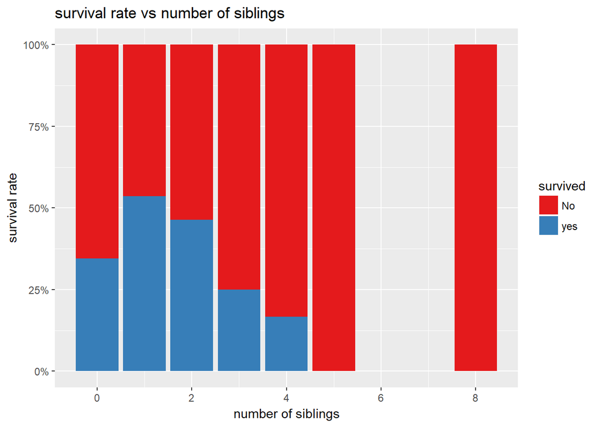

```r
ggplot(full %>% mutate(survived=case_when(survived==0 ~ "No", survived==1 ~'yes'))  %>% filter(set=='train'), aes(x=sibsp, fill=survived))+geom_bar(position = "fill")+scale_fill_brewer(palette="Set1")+ scale_y_continuous(labels = percent)+labs(x='number of siblings', y= "survival rate", title ="survival rate vs number of siblings")      #use RColorBrewer::display.brewer.all() to check pallet options
```

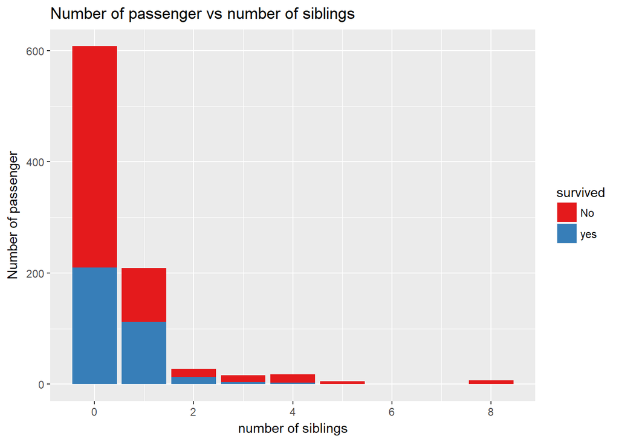

```r
ggplot(full %>% mutate(survived=case_when(survived==0 ~ "No", survived==1 ~'yes'))  %>% filter(set=='train'), aes(x=sibsp, fill=survived))+geom_bar()+scale_fill_brewer(palette="Set1")+labs(x='number of siblings', y= "Number of passenger", title ="Number of passenger vs number of siblings")      #use RColorBrewer::display.brewer.all() to check pallet options
```

#### Parch

```r
summary <- full %>% filter(set=='train') %>% group_by(parch) %>% summarise(passenger=n(),survived=sum(as.numeric(as.character(survived))), survival_rate= round(sum(as.numeric(as.character(survived)))*100/n()))
kable(summary)
```

| parch | passenger | survived | survival_rate |
| --- | --- | --- | --- |
| 0 | 678 | 233 | 34 |
| 1 | 118 | 65 | 55 |
| 2 | 80 | 40 | 50 |
| 3 | 5 | 3 | 60 |
| 4 | 4 | 0 | 0 |
| 5 | 5 | 1 | 20 |
| 6 | 1 | 0 | 0 |

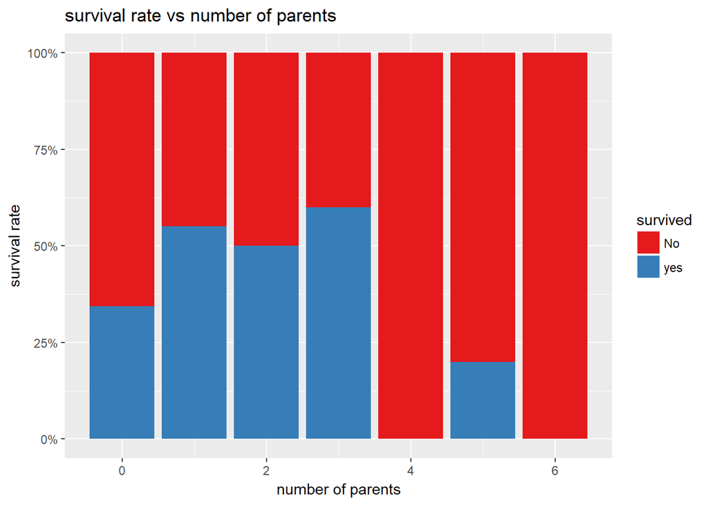

```r
ggplot(full %>% mutate(survived=case_when(survived==0 ~ "No", survived==1 ~'yes'))  %>% filter(set=='train'), aes(x=parch, fill=survived))+geom_bar(position = "fill")+scale_fill_brewer(palette="Set1")+ scale_y_continuous(labels = percent)+labs(x='number of parents', y= "survival rate", title ="survival rate vs number of parents")      #use RColorBrewer::display.brewer.all() to check pallet options
```

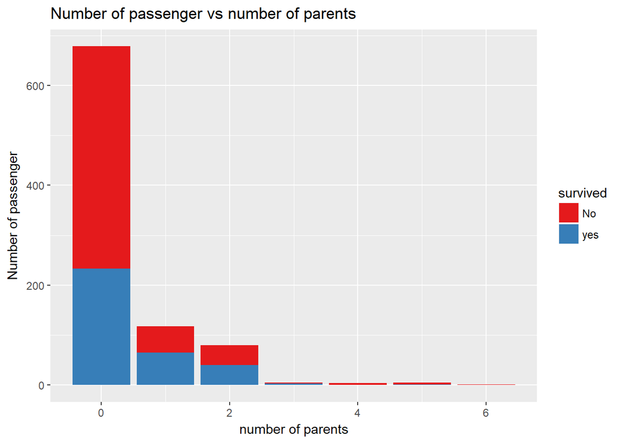

```r
ggplot(full %>% mutate(survived=case_when(survived==0 ~ "No", survived==1 ~'yes'))  %>% filter(set=='train'), aes(x=parch, fill=survived))+geom_bar()+scale_fill_brewer(palette="Set1")+labs(x='number of parents', y= "Number of passenger", title ="Number of passenger vs number of parents")      #use RColorBrewer::display.brewer.all() to check pallet options
```

#### Fare

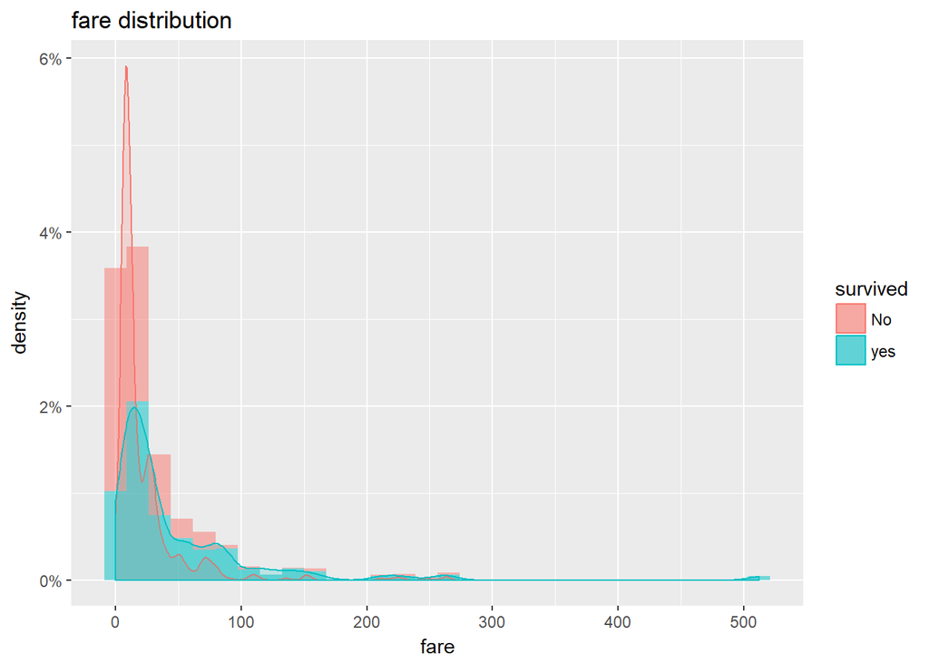

```r
ggplot(full %>% mutate(survived=case_when(survived==0 ~ "No", survived==1 ~'yes'))  %>% filter(set=='train'),aes(x=fare, fill=survived))+geom_histogram(aes(y=..density..), alpha=0.5)+geom_density(alpha=0.2,aes(colour=survived))+scale_y_continuous(label=percent)+labs(x="fare",y='density', title="fare distribution")
```

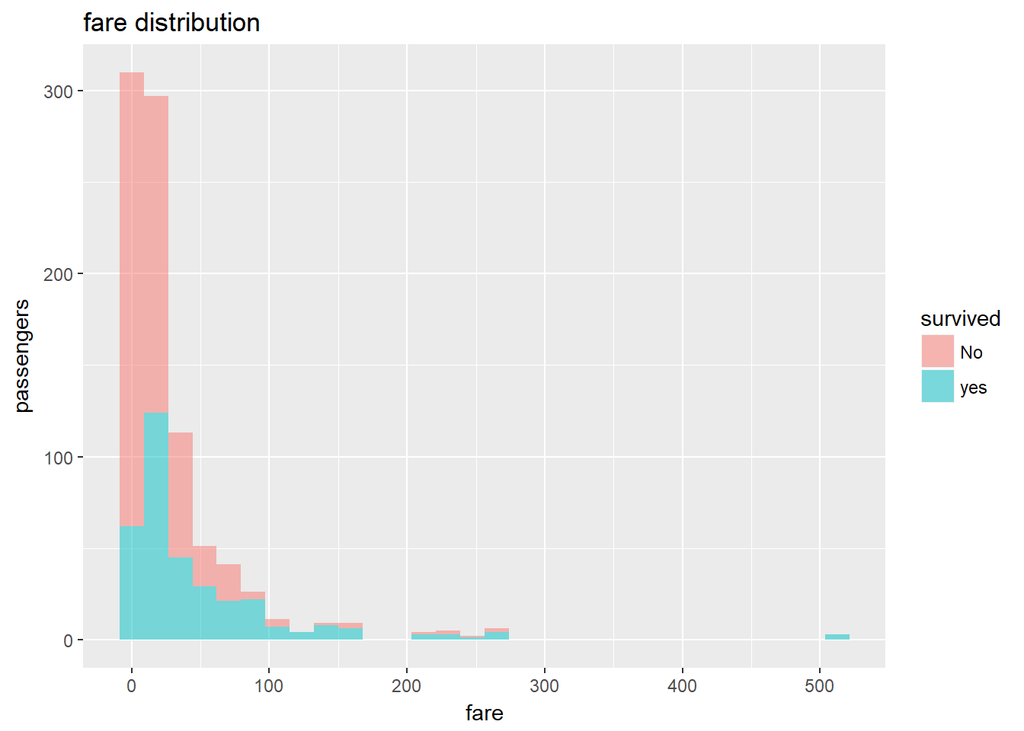

```r
ggplot(full %>% mutate(survived=case_when(survived==0 ~ "No", survived==1 ~'yes'))  %>% filter(set=='train'),aes(x=fare, fill=survived))+geom_histogram(alpha=0.5)+labs(x="fare",y='passengers', title="fare distribution")
```

#### Embarked

```r
summary <- full %>% filter(set=='train') %>% group_by(embarked) %>% summarise(passenger=n(),survived=sum(as.numeric(as.character(survived))), survival_rate= round(sum(as.numeric(as.character(survived)))*100/n()))
kable(summary)
```

| embarked | passenger | survived | survival_rate |
| --- | --- | --- | --- |
| C | 170 | 95 | 56 |
| Q | 77 | 30 | 39 |
| S | 644 | 217 | 34 |

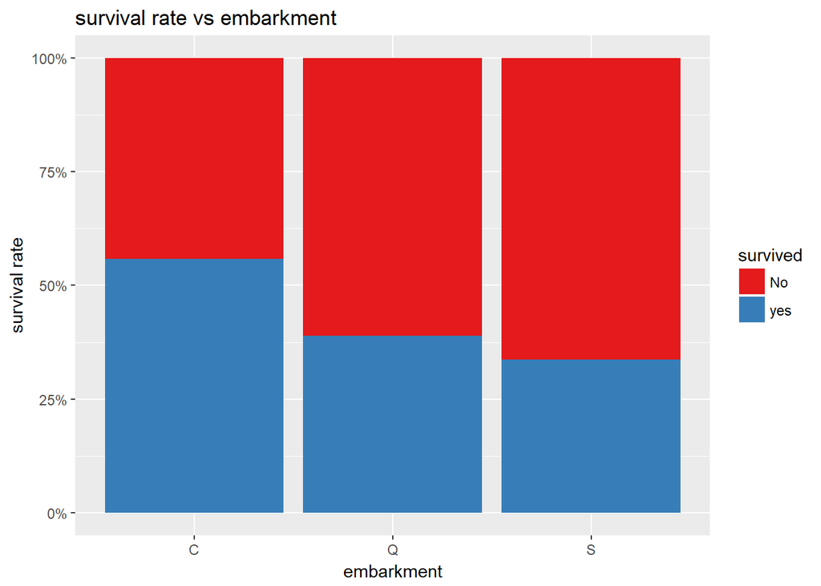

```r
ggplot(full %>% mutate(survived=case_when(survived==0 ~ "No", survived==1 ~'yes'))  %>% filter(set=='train'), aes(x=embarked, fill=survived))+geom_bar(position = "fill")+scale_fill_brewer(palette="Set1")+ scale_y_continuous(labels = percent)+labs(x='embarkment', y= "survival rate", title ="survival rate vs embarkment")      #use RColorBrewer::display.brewer.all() to check pallet options
```

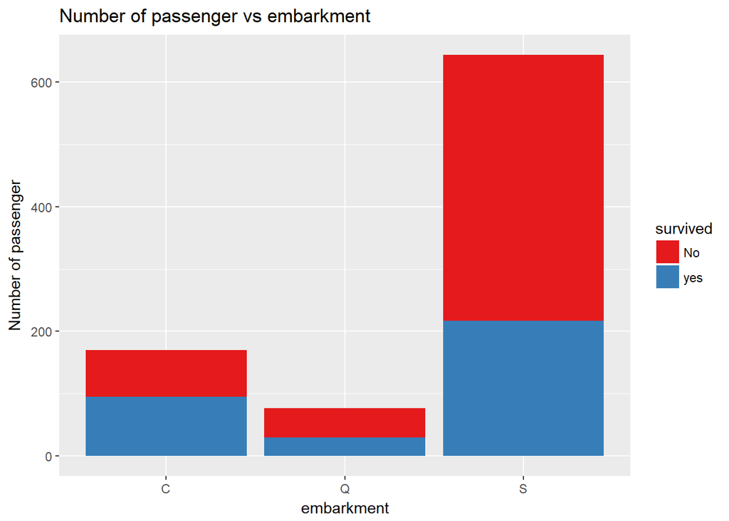

```r
ggplot(full %>% mutate(survived=case_when(survived==0 ~ "No", survived==1 ~'yes'))  %>% filter(set=='train'), aes(x=embarked, fill=survived))+geom_bar()+scale_fill_brewer(palette="Set1")+labs(x='embarkment', y= "Number of passenger", title ="Number of passenger vs embarkment")      #use RColorBrewer::display.brewer.all() to check pallet options
```

#### Title

```r
summary <- full %>% filter(set=='train') %>% group_by(title) %>% summarise(passenger=n(),survived=sum(as.numeric(as.character(survived))), survival_rate= round(sum(as.numeric(as.character(survived)))*100/n()))
kable(summary)
```

| title | passenger | survived | survival_rate |
| --- | --- | --- | --- |
| Master | 40 | 23 | 58 |
| Miss | 186 | 131 | 70 |
| Mr | 517 | 81 | 16 |
| Mrs | 126 | 100 | 79 |
| rare | 22 | 7 | 32 |

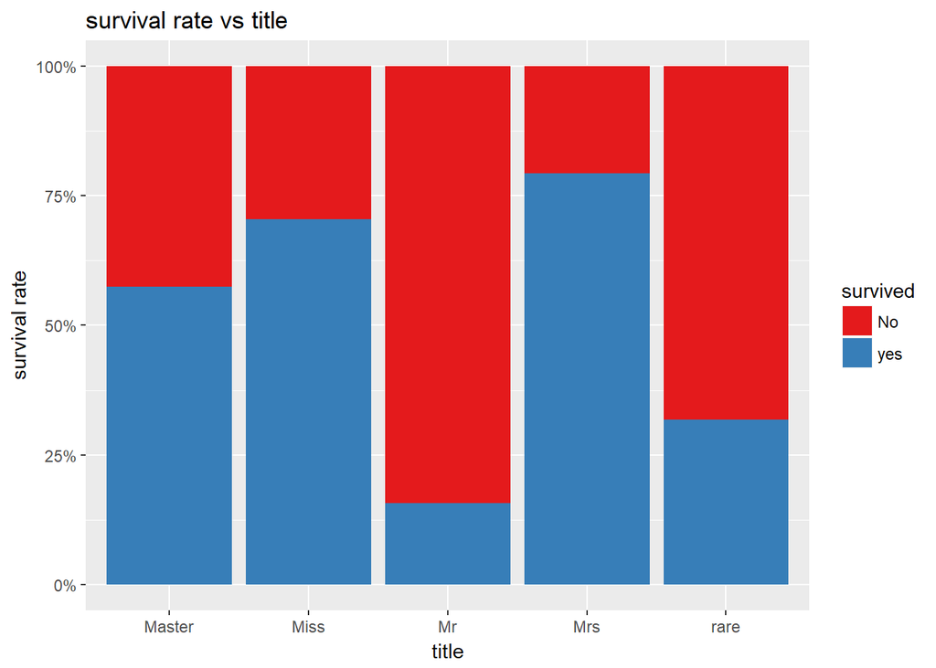

```r
ggplot(full %>% mutate(survived=case_when(survived==0 ~ "No", survived==1 ~'yes'))  %>% filter(set=='train'), aes(x=title, fill=survived))+geom_bar(position = "fill")+scale_fill_brewer(palette="Set1")+ scale_y_continuous(labels = percent)+labs(x='title', y= "survival rate", title ="survival rate vs title")      #use RColorBrewer::display.brewer.all() to check pallet options
```

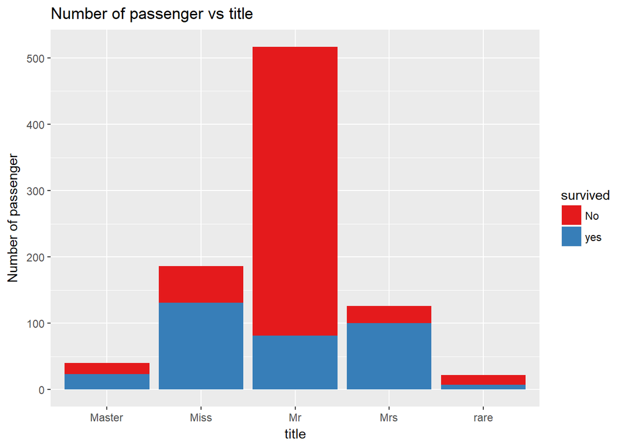

```r
ggplot(full %>% mutate(survived=case_when(survived==0 ~ "No", survived==1 ~'yes'))  %>% filter(set=='train'), aes(x=title, fill=survived))+geom_bar()+scale_fill_brewer(palette="Set1")+labs(x='title', y= "Number of passenger", title ="Number of passenger vs title")      #use RColorBrewer::display.brewer.all() to check pallet options
```

#### Family size

```r
summary <- full %>% filter(set=='train') %>% group_by(FamilySized) %>% summarise(passenger=n(),survived=sum(as.numeric(as.character(survived))), survival_rate= round(sum(as.numeric(as.character(survived)))*100/n()))
kable(summary)
```

| FamilySized | passenger | survived | survival_rate |
| --- | --- | --- | --- |
| Big | 62 | 10 | 16 |
| Single | 537 | 163 | 30 |
| Small | 292 | 169 | 58 |

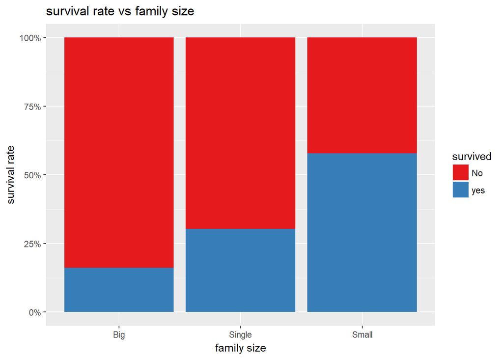

```r
ggplot(full %>% mutate(survived=case_when(survived==0 ~ "No", survived==1 ~'yes'))  %>% filter(set=='train'), aes(x=FamilySized, fill=survived))+geom_bar(position = "fill")+scale_fill_brewer(palette="Set1")+ scale_y_continuous(labels = percent)+labs(x='family size', y= "survival rate", title ="survival rate vs family size")      #use RColorBrewer::display.brewer.all() to check pallet options
```

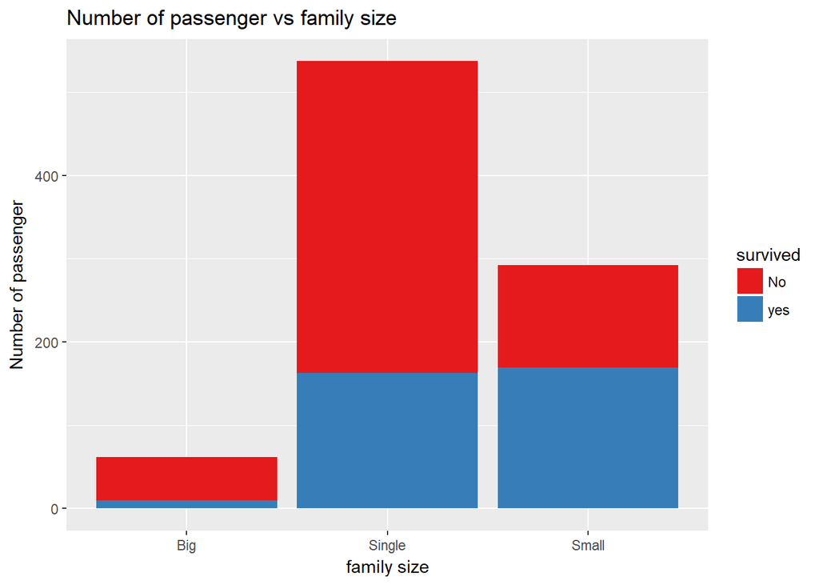

```r
ggplot(full %>% mutate(survived=case_when(survived==0 ~ "No", survived==1 ~'yes'))  %>% filter(set=='train'), aes(x=FamilySized, fill=survived))+geom_bar()+scale_fill_brewer(palette="Set1")+labs(x='family size', y= "Number of passenger", title ="Number of passenger vs family size")      #use RColorBrewer::display.brewer.all() to check pallet options
```

#### Ticket Group

```r
summary <- full %>% filter(set=='train') %>% group_by(ticketgroup) %>% summarise(passenger=n(),survived=sum(as.numeric(as.character(survived))), survival_rate= round(sum(as.numeric(as.character(survived)))*100/n()))
kable(summary)
```

| ticketgroup | passenger | survived | survival_rate |
| --- | --- | --- | --- |
| a | 29 | 2 | 7 |
| c | 47 | 16 | 34 |
| f | 11 | 5 | 45 |
| numeric3 | 2 | 0 | 0 |
| numeric4 | 97 | 36 | 37 |
| numeric5 | 131 | 81 | 62 |
| numeric6 | 415 | 133 | 32 |
| numeric7 | 16 | 4 | 25 |
| p | 65 | 42 | 65 |
| s | 65 | 21 | 32 |
| w | 13 | 2 | 15 |

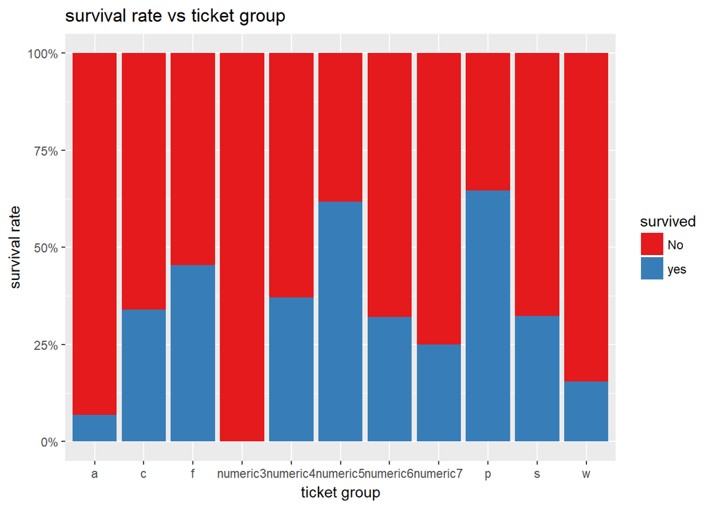

```r
ggplot(full %>% mutate(survived=case_when(survived==0 ~ "No", survived==1 ~'yes'))  %>% filter(set=='train'), aes(x=ticketgroup, fill=survived))+geom_bar(position = "fill")+scale_fill_brewer(palette="Set1")+ scale_y_continuous(labels = percent)+labs(x='ticket group', y= "survival rate", title ="survival rate vs ticket group")      #use RColorBrewer::display.brewer.all() to check pallet options
```

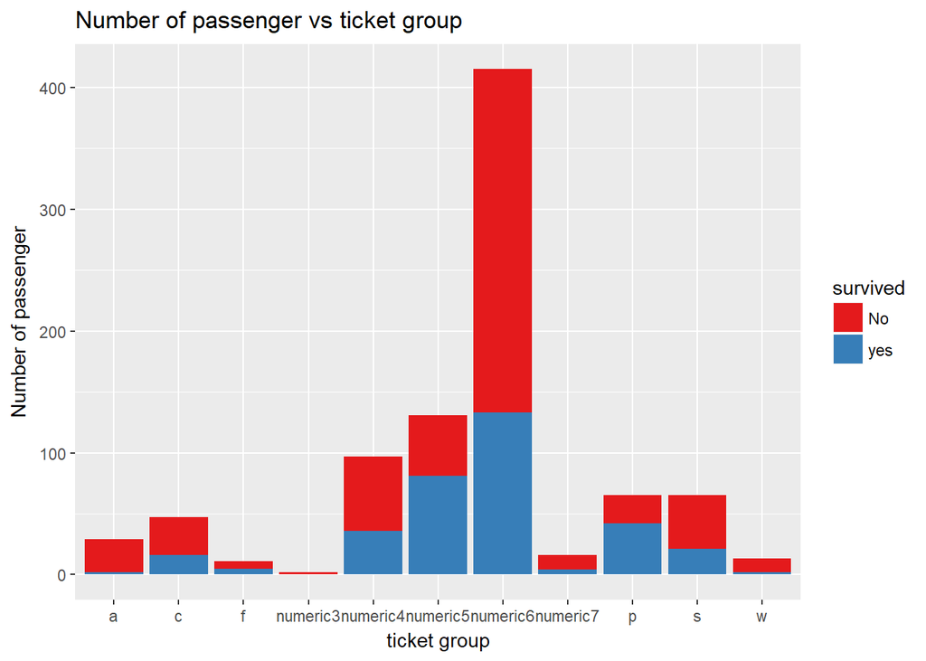

```r
ggplot(full %>% mutate(survived=case_when(survived==0 ~ "No", survived==1 ~'yes'))  %>% filter(set=='train'), aes(x=ticketgroup, fill=survived))+geom_bar()+scale_fill_brewer(palette="Set1")+labs(x='ticket group', y= "Number of passenger", title ="Number of passenger vs ticket group")      #use RColorBrewer::display.brewer.all() to check pallet options
```

## Feature Correlation

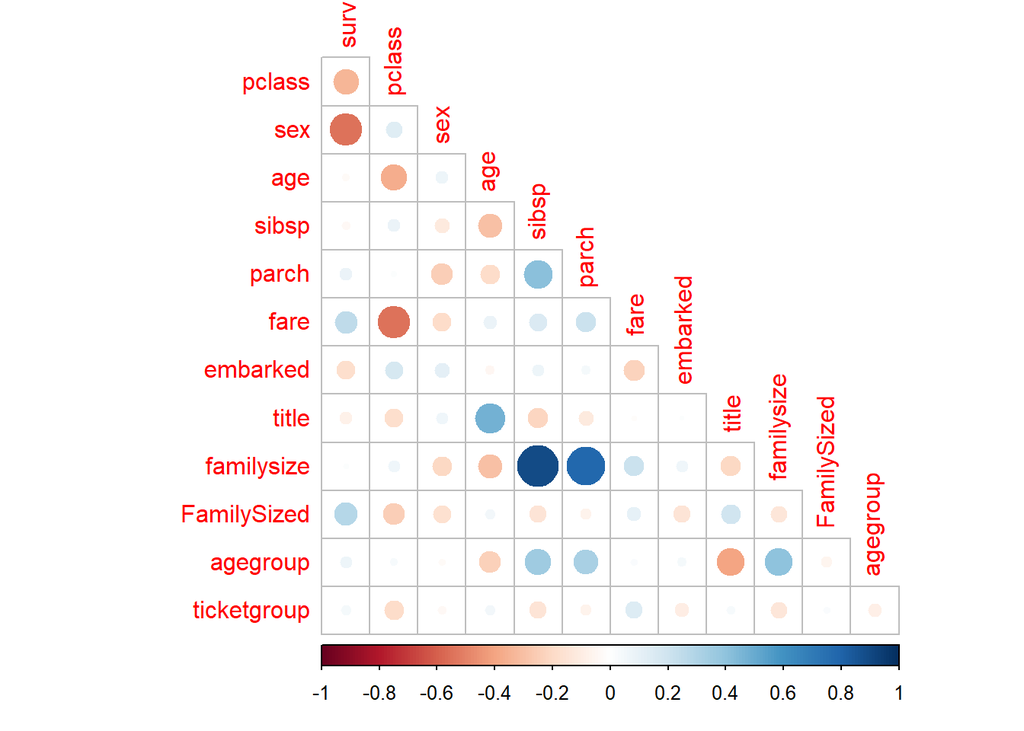

```r
#feature correlation
coor_tbl <- full %>% filter(set=="train")%>%select(-passengerid,-name,-ticket,-cabin,-set) %>% mutate_all(as.numeric)%>%cor(use="complete.obs")%>%corrplot(type="lower", diag=FALSE)
```

## Data Preperation for prediction

```r
#prep for prediction
set.seed(120)

train_dev <- full %>% filter(set=="train") %>% select(survived,pclass,sex,agegroup,ticketgroup,FamilySized,title,fare, embarked)
data_partition <- createDataPartition(train_dev$survived, p=0.8, list=F)

#Train
train_final <- train_dev[data_partition,]

#Development
dev_final <- train_dev[-data_partition,]

#test set for final prediction
test_final <- full %>% filter(set=="test") %>% select(survived,pclass,sex,agegroup,ticketgroup,FamilySized,title,fare, embarked)
```

## Prediction Models

### Classification Tree

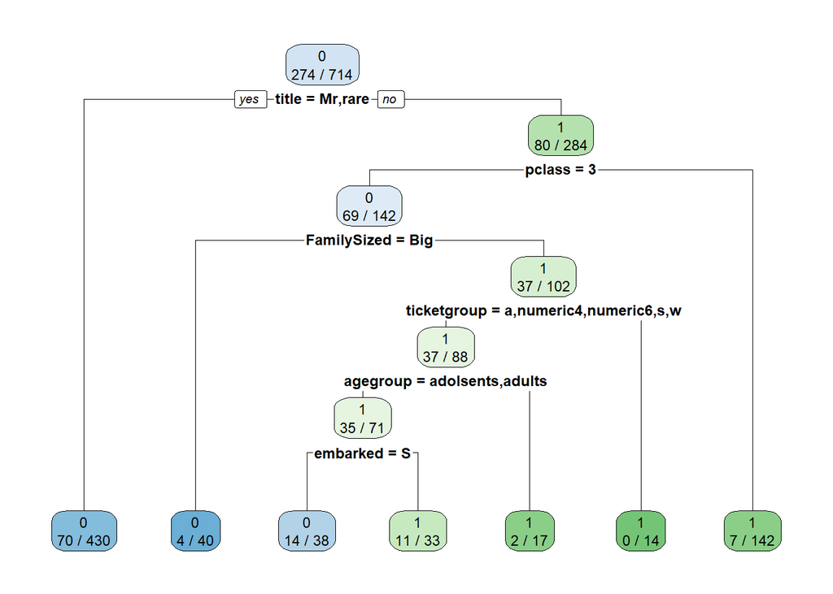

```r
model_dt <- rpart(survived~., data=train_final,method='class')
rpart.plot(model_dt,extra =  3)
```

```r
predict_train <- predict(model_dt,data=train_final,type = "class")
confusionMatrix(predict_train,train_final$survived)
```

```
## Confusion Matrix and Statistics
##
##           Reference
## Prediction   0   1
##          0 420  88
##          1  20 186
##
##                Accuracy : 0.8487
##                  95% CI : (0.8203, 0.8742)
##     No Information Rate : 0.6162
##     P-Value [Acc > NIR] : < 2.2e-16
##
##                   Kappa : 0.6645
##  Mcnemar's Test P-Value : 1.14e-10
##
##             Sensitivity : 0.9545
##             Specificity : 0.6788
##          Pos Pred Value : 0.8268
##          Neg Pred Value : 0.9029
##              Prevalence : 0.6162
##          Detection Rate : 0.5882
##    Detection Prevalence : 0.7115
##       Balanced Accuracy : 0.8167
##
##        'Positive' Class : 0
##
```

```r
predict_dev <- predict(model_dt, newdata = dev_final, type = "class")
confusionMatrix(predict_dev,dev_final$survived)
```

```
## Confusion Matrix and Statistics
##
##           Reference
## Prediction   0   1
##          0 102  22
##          1   7  46
##
##                Accuracy : 0.8362
##                  95% CI : (0.7732, 0.8874)
##     No Information Rate : 0.6158
##     P-Value [Acc > NIR] : 1.38e-10
##
##                   Kappa : 0.6388
##  Mcnemar's Test P-Value : 0.00933
##
##             Sensitivity : 0.9358
##             Specificity : 0.6765
##          Pos Pred Value : 0.8226
##          Neg Pred Value : 0.8679
##              Prevalence : 0.6158
##          Detection Rate : 0.5763
##    Detection Prevalence : 0.7006
##       Balanced Accuracy : 0.8061
##
##        'Positive' Class : 0
##
```